# Exploring the Prediction of Rent Rate using Neighboring Properties Data

Group 1

November 27, 2017

## 1) An examination of the distributions of the variables

```r
comm_prop <- read.csv("comm_prop.csv")
#comm_prop$W2MiDT <- factor(comm_prop$W2MiDT, labels = c("No", "Yes"))
head(comm_prop,5)
```

```
##   RentRate Age OperExp VacRate   SqFt Taxes W2MiDT
## 1     13.5   1    5.02    0.14 123000  2.21      0
## 2     12.0  14    8.19    0.27 104079  1.87      0
## 3     10.5  16    3.00    0.00  39998  0.72      0
## 4     15.0   4   10.70    0.05  57112  1.03      0
## 5     14.0  11    8.97    0.07  60000  1.08      0
```

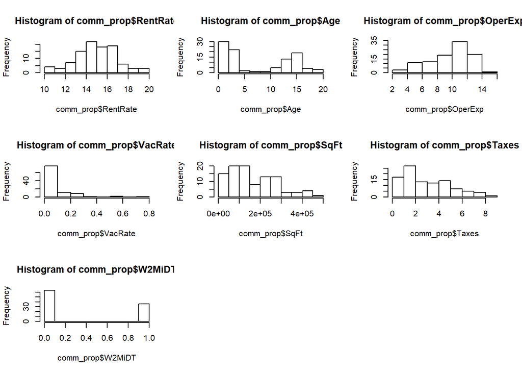

VacRate’s distribution contains strong Right/positive skewness. SqFt contains a slight amount of right skewness. OperExp contains a slight amount of left/negative skewness. Age has an unusual ditribution shape to it as well.

```r
round(cor(comm_prop),2)
```

```
##          RentRate   Age OperExp VacRate SqFt Taxes W2MiDT
## RentRate     1.00 -0.27    0.50   -0.04 0.58  0.58   0.70
## Age         -0.27  1.00    0.28   -0.19 0.27  0.27  -0.31
## OperExp      0.50  0.28    1.00   -0.37 0.47  0.47   0.23
## VacRate     -0.04 -0.19   -0.37    1.00 0.03  0.03   0.14
## SqFt         0.58  0.27    0.47    0.03 1.00  1.00   0.37
## Taxes        0.58  0.27    0.47    0.03 1.00  1.00   0.37
## W2MiDT       0.70 -0.31    0.23    0.14 0.37  0.37   1.00
```

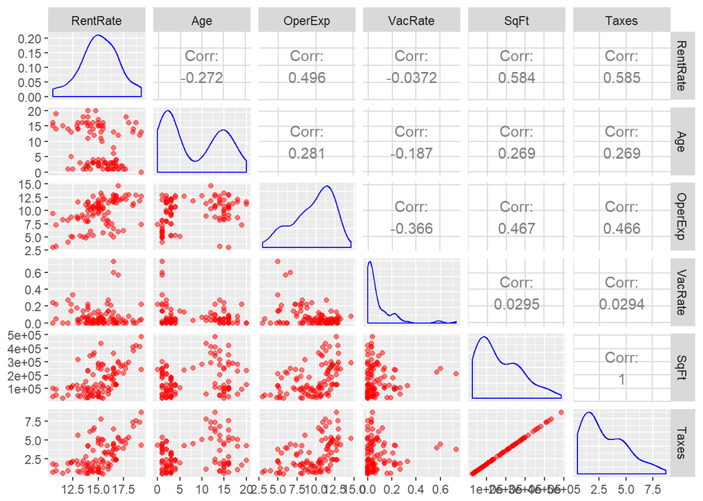

```r
library(GGally)
ggpairs(comm_prop[,1:6] ,
        lower = list(continuous = wrap("points", color = "red", alpha = 0.5)),
        diag = list(continuous = wrap("densityDiag",  color = "blue", alpha = 0.5)))
```

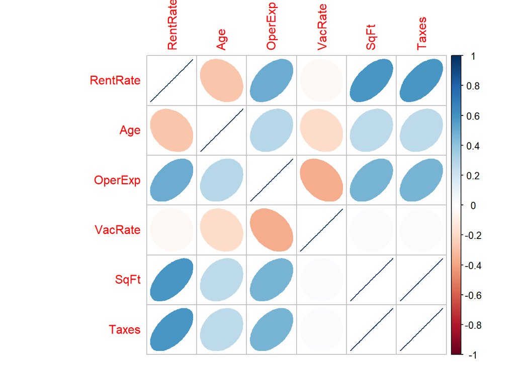

```r
library(corrplot)
corrplot(cor(comm_prop[,c(1:6)]), method="ellipse")
```

RentRate and OperExp have a moderate correlation. RentRate and SqFt have a moderate correlation as well. RentRate and Taxes share the same correlation with .58. W2MiDT has the strongest correlation with RentRate with a correlation coefficent of.70. SqFt and Taxes have a perfect correlation with 1.00.

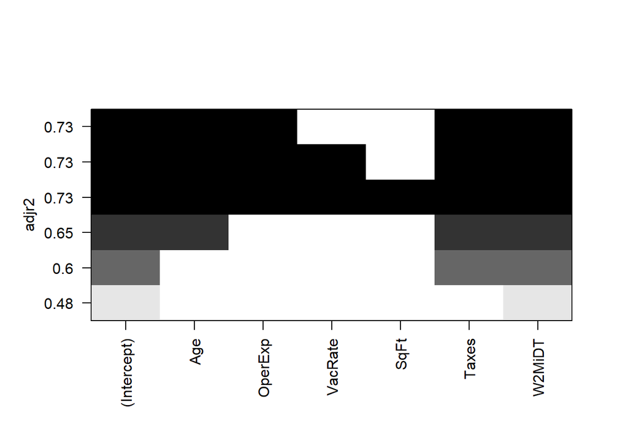

```r
library(leaps)
subsets <- regsubsets(RentRate ~ ., data=comm_prop)
plot(subsets, scale="adjr2")
```

#### ^^ Based on the plot, our variable selection should be Age, OperExp, Taxes, and W2MiDT.

```r
m <- lm(RentRate ~ Age+OperExp+W2MiDT+Taxes, data=comm_prop) # + Age:VacRate + OperExp:W2MiDT + SqFt:W2MiDT, data=comm_prop)
summary(m) #added interactive terms from Malini's result and got potentially more accurate model
```

```
##
## Call:
## lm(formula = RentRate ~ Age + OperExp + W2MiDT + Taxes, data = comm_prop)
##
## Residuals:
##      Min       1Q   Median       3Q      Max
## -2.90320 -0.58110 -0.03581  0.57358  2.54945
##
## Coefficients:
##             Estimate Std. Error t value Pr(>|t|)
## (Intercept) 12.04883    0.37890  31.799  < 2e-16 ***
## Age         -0.10398    0.01843  -5.642 1.73e-07 ***
## OperExp      0.23731    0.04405   5.387 5.18e-07 ***
## W2MiDT       1.43475    0.25386   5.652 1.66e-07 ***
## Taxes        0.36898    0.06173   5.977 3.95e-08 ***
## ---
## Signif. codes:  0 '***' 0.001 '**' 0.01 '*' 0.05 '.' 0.1 ' ' 1
##
## Residual standard error: 0.9859 on 95 degrees of freedom
## Multiple R-squared:  0.7422, Adjusted R-squared:  0.7313
## F-statistic: 68.36 on 4 and 95 DF,  p-value: < 2.2e-16
```

# Review and Interpretation of diagnostic plots

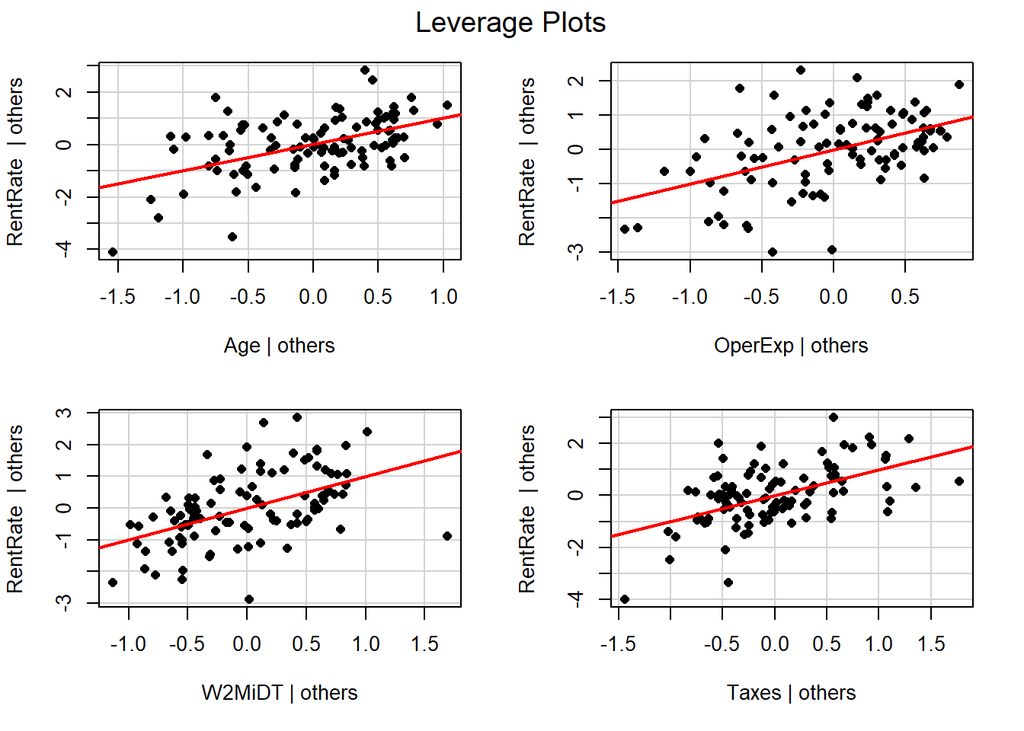

```r
leveragePlots(m,pch=16)
```

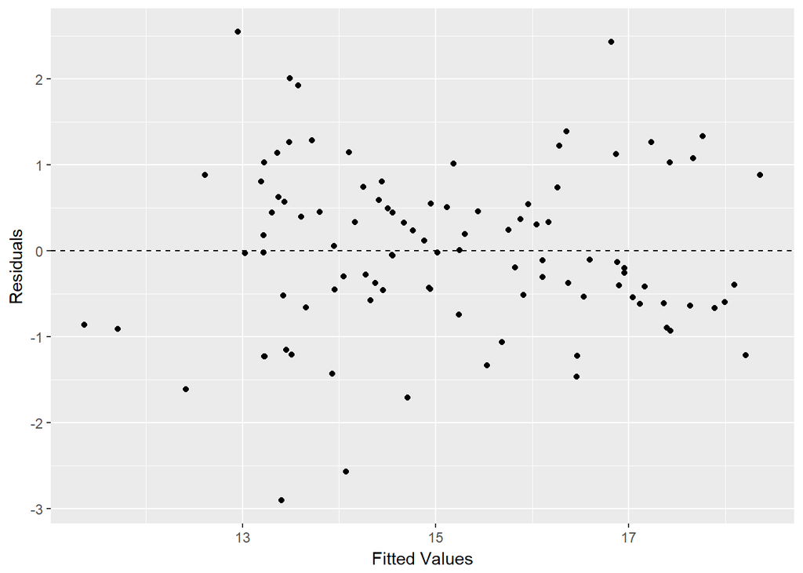

```r
m_df <- fortify(m)

ggplot(m_df, aes(x=.fitted, y=.resid)) +
  geom_point() +
  geom_hline(yintercept = 0, linetype = 2) +
  labs(x="Fitted Values", y="Residuals")
```

**Checking for constant variance**

```r
car::ncvTest(m)
```

```
## Non-constant Variance Score Test
## Variance formula: ~ fitted.values
## Chisquare = 3.278764    Df = 1     p = 0.07018175
```

**Conclusion: Variance is constant**

**Checking for Normality of Residuals**

```r
shapiro.test(m$residuals)
```

```
##
##  Shapiro-Wilk normality test
##
## data:  m$residuals
## W = 0.98934, p-value = 0.6117
```

**The residuals are approximately normal**

#### Visual Representation of Normality and Constant Variance Tests

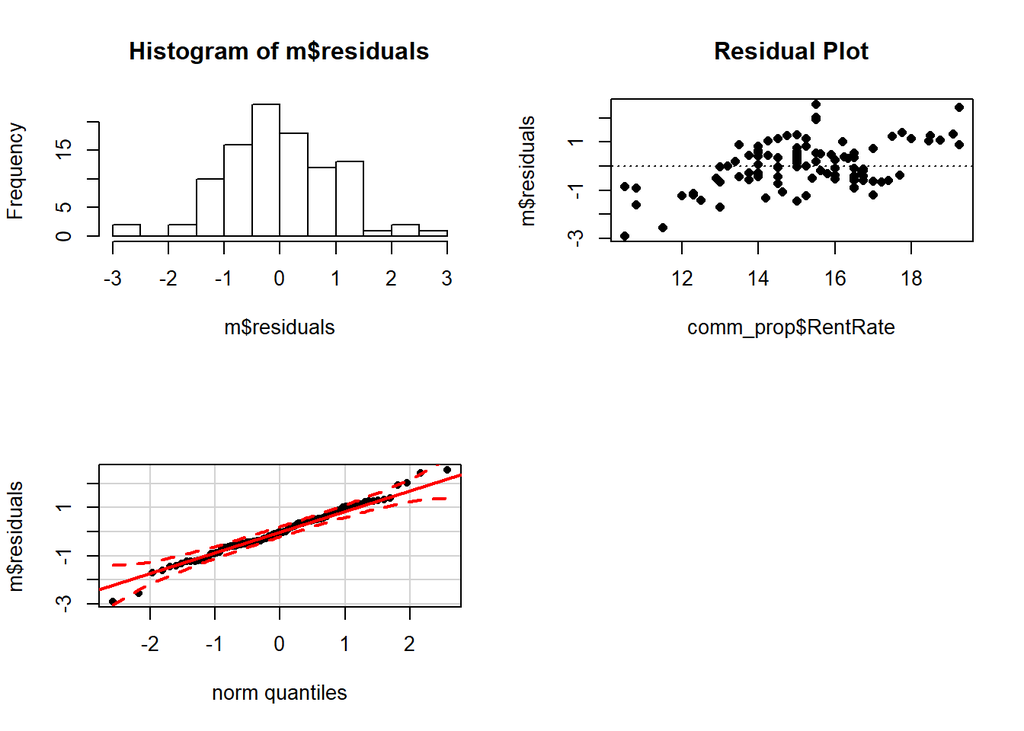

```r
par(mfrow=c(2,2))
hist(m$residuals)
plot(m$residuals ~ comm_prop$RentRate,pch=16, main="Residual Plot")
abline(h = 0, lty = 3)  # adds a horizontal dashed line at y = 0
qqPlot(m$residuals, pch=16)
# qqline(m$residuals)
```

Tails are a bit out, which could suggest non-constant variance. However, we formally tested via the ncvTest and did not reject the null hypothesis.

**Test for Multicolinearity**

```r
car::vif(m)
```

```
##      Age  OperExp   W2MiDT    Taxes
## 1.459607 1.366669 1.527436 1.582151
```

**Results suggest no Multicolinearity**

Start on Predict: We are 95% confidence that the value of RentRate will be between 14.17338 and 18.20759.

```r
new_obs = data.frame(Age=9, SqFt=40,OperExp=13,Taxes=5.40,W2MiDT=0)
predict(m, newdata = new_obs, interval="predict")
```

```
##        fit      lwr      upr
## 1 16.19049 14.17338 18.20759
```

**Stepwise regression by manually removing variables**